# Question

Three people are buying fruit, and there are five grocery stores. Each person has a shopping list dictating how many pounds of each fruit to buy. Each store has different unit costs of fruit.

In order to consider the **total** cost for each person at each store, we can use [matrix multiplication](https://en.wikipedia.org/wiki/Matrix_multiplication). In order to help visualize matrix multiplication, the shopping lists are shown as a matrix on the bottom-left, the unit prices as a matrix on top-right, and the resulting matrix of totals in the bottom-right.

A peculiarity of matrix multiplication requires the **columns** of the first matrix to “match” the **rows** of the second matrix. In this case, notice the various fruits correspond to columns in the first matrix (bottom-left) and rows in the second matrix (top-right). This visualization is an attempt to make this seem more natural.

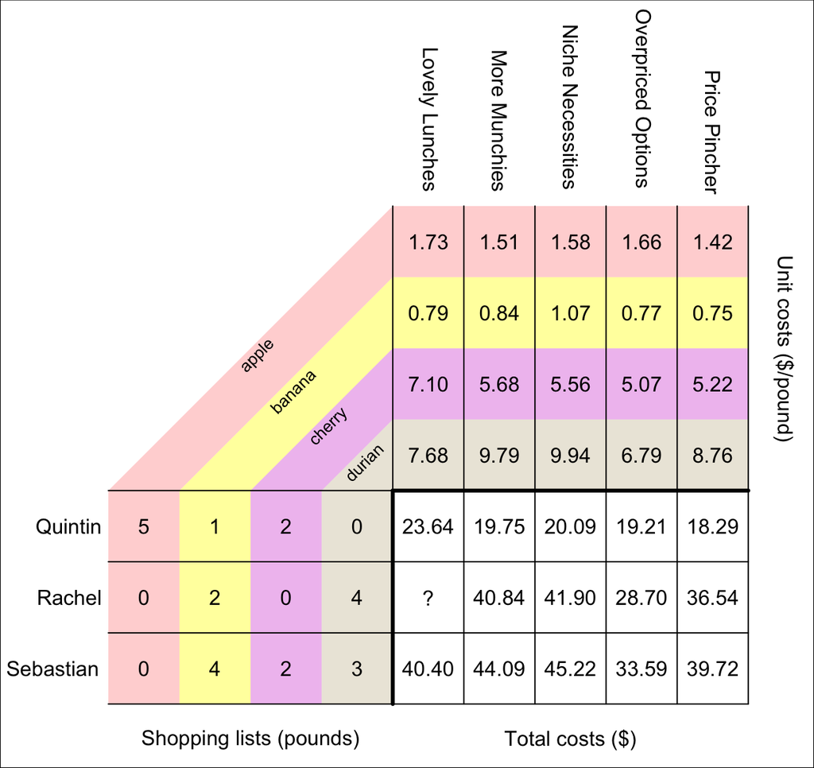

What is the total cost of Rachel shopping at Lovely Lunches?

# Solution

Rachel wishes to buy 0 lb of apple, 2 lb of banana, 0 lb of cherry, and 4 lb of durian. At Lovely Lunches, the unit price of apple is $1.73/lb, the unit price of banana is $0.79/lb, the unit price of cherry is $7.10/lb, and the unit price of durian is $7.68/lb.

To find the total cost of Rachel’s shopping trip, multiply each quantity by its corresponding unit price and then add up all those products.

$$(0\cdot1.73)~+~(2\cdot0.79)~+~(0\cdot7.1)~+~(4\cdot7.68)$$
$$0~+~1.58~+~0~+~30.72$$
$$32.30$$

So, the total cost of Rachel shopping at Lovely Lunches is $32.30.

In standard math notation, the matrix multiplication would be shown as:

$$\begin{bmatrix}
5 & 1 & 2 & 0\\
0 & 2 & 0 & 4\\
0 & 4 & 2 & 3
\end{bmatrix} \cdot \begin{bmatrix}
1.73 & 1.51 & 1.58 & 1.66 & 1.42\\
0.79 & 0.84 & 1.07 & 0.77 & 0.75\\
7.1 & 5.68 & 5.56 & 5.07 & 5.22\\
7.68 & 9.79 & 9.94 & 6.79 & 8.76
\end{bmatrix} ~=~ \begin{bmatrix}
23.64 & 19.75 & 20.09 & 19.21 & 18.29\\
32.3 & 40.84 & 41.9 & 28.7 & 36.54\\
40.4 & 44.09 & 45.22 & 33.59 & 39.72
\end{bmatrix}$$

# Meta-information

extype: num exsolution: 32.3 exname: groceries_get_total extol: 0.005